# GCN Step-by-Step:

This is the second notebook for the GNN learning with movie dataset.

This notebook shows **exactly** what happens inside a GCN layer using your actual MovieLens data. We will not focus on the training step, however we will have a deep understanding about what happens in GCN layer.

You can see what's happening inside GCN layer after step 7.

- Step 1: Load Actual MovieLens Data

  ```
    Total ratings: 100836
    Total users: 610
    Total movies: 9724
  ```

- Step 2: Create a TINY Subset for Understanding

  ```
    TOTAL: 3 users + 10 movies = 13 nodes
  ```

- Step 3: Build the Edge List (Who is Connected to Whom)

  ```
    Example:

    Edge 0: Node 0 (User) -> Node 3 (Movie)
    Edge 1: Node 3 (Movie) -> Node 0 (User)
    Edge 2: Node 0 (User) -> Node 4 (Movie)
    Edge 3: Node 4 (Movie) -> Node 0 (User)
  ```

- Step 4: Find Neighbors for Each Node

  ```
    Node 2 (User 5):
      Neighbors (node indices): [np.int64(3), np.int64(7), np.int64(10)]
      Neighbors (movies): ["'Toy Story (1995)'", "'Usual Suspects, The '", "'Braveheart (1995)'"]
      Degree (# of neighbors): 3
  ```

- Step 5: Initialize Node Embeddings

  ```
    --- USER EMBEDDINGS ---
    Node 0 (User 1): [ 0.248 -0.069  0.324  0.762]
    Node 1 (User 4): [-0.117 -0.117  0.79   0.384]

    --- MOVIE EMBEDDINGS ---
    Node 3 ('Toy Story (1995)'): [ 0.121 -0.957 -0.862 -0.281]
    Node 4 ('Grumpier Old Men (19'): [-0.506  0.157 -0.454 -0.706]
  ```

- Step 7: GCN LAYER - The Main Computation!
- STEP 7.1: Get neighbor embeddings

  ```
    Example:
    Node 4 ('Grumpier Old Men (1995)'): [-0.506  0.157 -0.454 -0.706]
    Node 5 ('Heat (1995)'): [ 0.733 -0.113  0.034 -0.712]
  ```

- STEP 7.2: Normalize by degree

  ```
    Example:
     Node 4 ('Grumpier Old Men (19'):
        Original h_u:    [-0.506  0.157 -0.454 -0.706]
        degree[u] = 1, degree[v] = 10
        norm_factor = sqrt(1 × 10) = sqrt(10) = 3.162
        Normalized h_u:  [-0.16   0.05  -0.144 -0.223]
  ```

- STEP 7.3: Sum normalized embeddings

  ```
    = [-0.095 -1.071 -0.636 -0.352]
  ```

- STEP 7.4: Apply weight matrix W

  ```
    Weight matrix W (shape: (4, 4)):
    [[-0.338  0.306  0.515  0.466]
     [-0.42  -0.155  0.166  0.488]
     [-0.24  -0.093 -0.553 -0.598]
     [ 0.406  0.678 -0.036  0.502]]

    Matrix multiplication: W @ aggregated
      (4, 4) @ (4,) = (4,)
  ```

- STEP 7.5: Add bias
- STEP 7.6: Apply ReLU activation
- Step 8: Do This For ALL Nodes

  ```
    APPLYING GCN LAYER TO ALL NODES
    ======================================================================
    Node  0 (User 1                   ): [ 0.248 -0.069  0.324  0.762] -> [0.    0.    0.721 0.   ]
    Node  1 (User 4                   ): [-0.117 -0.117  0.79   0.384] -> [0.    0.008 0.224 0.184]
  ```

- Step 9: Split Into User and Movie Embeddings
- Step 10: Predict a Rating!

  ```
    Dot product (element-wise multiply then sum):
      [0.    0.    0.721 0.   ]
    × [0.103 0.    0.004 0.241]
    = [0.    0.    0.003 0.   ]
  ```

Let's analyze the data at first.

```python
import numpy as np
import pandas as pd
import matplotlib.pyplot as plt
import seaborn as sns
import networkx as nx
from collections import defaultdict
import warnings
warnings.filterwarnings('ignore')

# PyTorch
import torch
import torch.nn as nn
import torch.nn.functional as F
from torch.optim import Adam

# PyTorch Geometric
try:
    from torch_geometric.data import Data, HeteroData
    from torch_geometric.nn import GCNConv, SAGEConv, GATConv, LGConv
    from torch_geometric.utils import to_networkx, negative_sampling
    print("✅ PyTorch Geometric loaded successfully!")
except ImportError:
    print("❌ PyTorch Geometric not installed. Run:")
    print("pip install torch-geometric")

# Sklearn for evaluation
from sklearn.model_selection import train_test_split
from sklearn.metrics import mean_squared_error, mean_absolute_error

# For interactive plots
import plotly.express as px
import plotly.graph_objects as go
from plotly.subplots import make_subplots

# Set random seeds for reproducibility
np.random.seed(42)
torch.manual_seed(42)

print(f"PyTorch version: {torch.__version__}")
print(f"CUDA available: {torch.cuda.is_available()}")
```

```
✅ PyTorch Geometric loaded successfully!
PyTorch version: 2.9.1
CUDA available: False
```

## Step 1: Load Actual MovieLens Data

```python
# Load the data
df_ratings = pd.read_csv('/Users/pelinbalci/PycharmProjects/MovieRecommendation/data/ml-latest-small/ratings.csv')
df_movies = pd.read_csv('/Users/pelinbalci/PycharmProjects/MovieRecommendation/data/ml-latest-small/movies.csv')


print("=" * 50)
print("DATASET OVERVIEW")
print("=" * 50)
print(f"Number of ratings: {len(df_ratings):,}")
print(f"Number of users: {df_ratings['userId'].nunique():,}")
print(f"Number of movies: {df_ratings['movieId'].nunique():,}")
print(f"Rating range: {df_ratings['rating'].min()} - {df_ratings['rating'].max()}")
print(f"Sparsity: {1 - len(df_ratings) / (df_ratings['userId'].nunique() * df_ratings['movieId'].nunique()):.4%}")
```

```
==================================================
DATASET OVERVIEW
==================================================
Number of ratings: 100,836
Number of users: 610
Number of movies: 9,724
Rating range: 0.5 - 5.0
Sparsity: 98.3000%
```

## Data Analysis

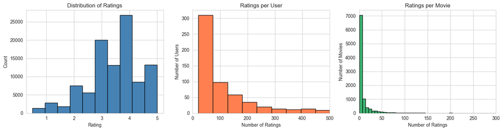

```python
# Visualize rating distribution
fig, axes = plt.subplots(1, 3, figsize=(15, 4))

# Rating distribution
axes[0].hist(df_ratings['rating'], bins=10, edgecolor='black', color='steelblue')
axes[0].set_xlabel('Rating')
axes[0].set_ylabel('Count')
axes[0].set_title('Distribution of Ratings')

# Ratings per user
user_counts = df_ratings.groupby('userId').size()
axes[1].hist(user_counts, bins=50, edgecolor='black', color='coral')
axes[1].set_xlabel('Number of Ratings')
axes[1].set_ylabel('Number of Users')
axes[1].set_title('Ratings per User')
axes[1].set_xlim(0, 500)

# Ratings per movie
movie_counts = df_ratings.groupby('movieId').size()
axes[2].hist(movie_counts, bins=50, edgecolor='black', color='mediumseagreen')
axes[2].set_xlabel('Number of Ratings')
axes[2].set_ylabel('Number of Movies')
axes[2].set_title('Ratings per Movie')
axes[2].set_xlim(0, 300)

plt.tight_layout()
plt.show()
```

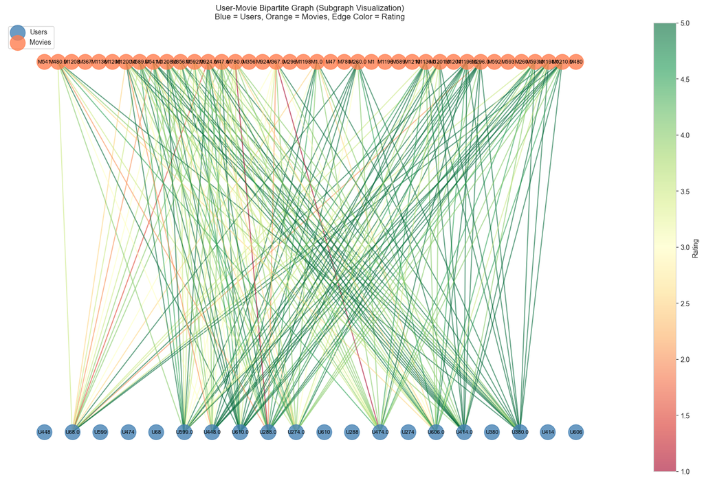

```python
# Visualize a small subgraph
def visualize_subgraph(df, num_users_to_show=10, num_movies_to_show=20):
    """
    Visualize a small portion of the user-movie graph.
    """
    # Select top users by number of ratings
    top_users = df.groupby('userId').size().nlargest(num_users_to_show).index.tolist()

    # Get their rated movies
    subset_df = df[df['userId'].isin(top_users)]
    top_movies = subset_df.groupby('movieId').size().nlargest(num_movies_to_show).index.tolist()

    # Filter to only these users and movies
    viz_df = subset_df[subset_df['movieId'].isin(top_movies)]

    # Create NetworkX graph
    G = nx.Graph()

    # Add user nodes
    for user in viz_df['userId'].unique():
        G.add_node(f"U{user}", node_type='user')

    # Add movie nodes
    for movie in viz_df['movieId'].unique():
        title = df_movies[df_movies['movieId'] == movie]['title'].values[0][:20]
        G.add_node(f"M{movie}", node_type='movie', title=title)

    # Add edges with ratings
    for _, row in viz_df.iterrows():
        G.add_edge(f"U{row['userId']}", f"M{row['movieId']}", rating=row['rating'])

    # Draw the graph
    plt.figure(figsize=(16, 10))

    # Position nodes
    pos = nx.bipartite_layout(G,
                              [n for n in G.nodes() if n.startswith('U')],
                              align='horizontal')

    # Color nodes by type
    user_nodes = [n for n in G.nodes() if n.startswith('U')]
    movie_nodes = [n for n in G.nodes() if n.startswith('M')]

    # Draw
    nx.draw_networkx_nodes(G, pos, nodelist=user_nodes, node_color='steelblue',
                          node_size=500, alpha=0.8, label='Users')
    nx.draw_networkx_nodes(G, pos, nodelist=movie_nodes, node_color='coral',
                          node_size=500, alpha=0.8, label='Movies')

    # Edge colors based on rating
    edge_colors = [G[u][v]['rating'] for u, v in G.edges()]
    edges = nx.draw_networkx_edges(G, pos, edge_color=edge_colors,
                                   edge_cmap=plt.cm.RdYlGn, width=1.5, alpha=0.6)

    # Labels
    nx.draw_networkx_labels(G, pos, font_size=8)

    plt.colorbar(edges, label='Rating')
    plt.legend(loc='upper left')
    plt.title('User-Movie Bipartite Graph (Subgraph Visualization)\n'
              'Blue = Users, Orange = Movies, Edge Color = Rating')
    plt.axis('off')
    plt.tight_layout()
    plt.show()

    return G

subgraph = visualize_subgraph(df_ratings)
```

```python
# Interactive visualization with Plotly
def interactive_graph_viz(df, num_users=15, num_movies=30):
    """
    Create an interactive visualization using Plotly.
    """
    # Select subset
    top_users = df.groupby('userId').size().nlargest(num_users).index.tolist()
    subset_df = df[df['userId'].isin(top_users)]
    top_movies = subset_df.groupby('movieId').size().nlargest(num_movies).index.tolist()
    viz_df = subset_df[subset_df['movieId'].isin(top_movies)]

    # Create graph
    G = nx.Graph()
    for user in viz_df['userId'].unique():
        G.add_node(f"U{user}", node_type='user')
    for movie in viz_df['movieId'].unique():
        title = df_movies[df_movies['movieId'] == movie]['title'].values[0]
        G.add_node(f"M{movie}", node_type='movie', title=title)
    for _, row in viz_df.iterrows():
        G.add_edge(f"U{row['userId']}", f"M{row['movieId']}", rating=row['rating'])

    # Layout
    pos = nx.spring_layout(G, k=2, iterations=50, seed=42)

    # Extract positions
    edge_x, edge_y = [], []
    for edge in G.edges():
        x0, y0 = pos[edge[0]]
        x1, y1 = pos[edge[1]]
        edge_x.extend([x0, x1, None])
        edge_y.extend([y0, y1, None])

    edge_trace = go.Scatter(
        x=edge_x, y=edge_y,
        line=dict(width=0.5, color='#888'),
        hoverinfo='none',
        mode='lines'
    )

    # Node positions
    node_x, node_y, node_text, node_color = [], [], [], []
    for node in G.nodes():
        x, y = pos[node]
        node_x.append(x)
        node_y.append(y)
        if node.startswith('U'):
            node_text.append(f"User {node[1:]}\nRatings: {G.degree(node)}")
            node_color.append(0)
        else:
            title = G.nodes[node].get('title', 'Unknown')
            node_text.append(f"{title}\nRatings: {G.degree(node)}")
            node_color.append(1)

    node_trace = go.Scatter(
        x=node_x, y=node_y,
        mode='markers',
        hoverinfo='text',
        text=node_text,
        marker=dict(
            showscale=False,
            color=node_color,
            colorscale=[[0, 'steelblue'], [1, 'coral']],
            size=15,
            line_width=2
        )
    )

    fig = go.Figure(data=[edge_trace, node_trace],
                   layout=go.Layout(
                       title='Interactive User-Movie Graph',
                       #titlefont_size=16,
                       showlegend=False,
                       hovermode='closest',
                       xaxis=dict(showgrid=False, zeroline=False, showticklabels=False),
                       yaxis=dict(showgrid=False, zeroline=False, showticklabels=False)
                   ))
    fig.show()

interactive_graph_viz(df_ratings)
```

## Step 2: Create a TINY Subset for Understanding

Let's use just 5 users and their movies so we can see every number.

```python
# Take only first 5 users
small_df = df_ratings[df_ratings['userId'].isin([1, 2, 3, 4, 5])].copy()

# Get unique movies these users rated
unique_movies = small_df['movieId'].unique()
print(f"5 users rated {len(unique_movies)} unique movies")

# Let's take only first 10 movies to keep it tiny
movies_to_keep = unique_movies[:10]
small_df = small_df[small_df['movieId'].isin(movies_to_keep)].copy()

print(f"\nFiltered to {len(small_df)} ratings")
print(small_df)
```

```
5 users rated 481 unique movies

Filtered to 14 ratings
     userId  movieId  rating  timestamp
0         1        1     4.0  964982703
1         1        3     4.0  964981247
2         1        6     4.0  964982224
3         1       47     5.0  964983815
4         1       50     5.0  964982931
5         1       70     3.0  964982400
6         1      101     5.0  964980868
7         1      110     4.0  964982176
8         1      151     5.0  964984041
9         1      157     5.0  964984100
303       4       47     2.0  945173425
516       5        1     4.0  847434962
521       5       50     4.0  847434881
523       5      110     4.0  847434880
```

```python
# Create mappings: original IDs -> 0, 1, 2, ...
unique_users = sorted(small_df['userId'].unique())
unique_movies = sorted(small_df['movieId'].unique())

user_to_idx = {user: idx for idx, user in enumerate(unique_users)}
movie_to_idx = {movie: idx for idx, movie in enumerate(unique_movies)}

num_users = len(unique_users)
num_movies = len(unique_movies)
num_nodes = num_users + num_movies

print("USER MAPPING (userId -> node index):")
for user, idx in user_to_idx.items():
    print(f"  User {user} -> Node {idx}")

print(f"\nMOVIE MAPPING (movieId -> node index):")
print(f"  (Movie indices start at {num_users} because users come first)")
for movie, idx in movie_to_idx.items():
    movie_title = df_movies[df_movies['movieId'] == movie]['title'].values[0][:30]
    print(f"  Movie {movie} ({movie_title}...) -> Node {num_users + idx}")

print(f"\n" + "="*50)
print(f"TOTAL: {num_users} users + {num_movies} movies = {num_nodes} nodes")
```

```
USER MAPPING (userId -> node index):
  User 1 -> Node 0
  User 4 -> Node 1
  User 5 -> Node 2

MOVIE MAPPING (movieId -> node index):
  (Movie indices start at 3 because users come first)
  Movie 1 (Toy Story (1995)...) -> Node 3
  Movie 3 (Grumpier Old Men (1995)...) -> Node 4
  Movie 6 (Heat (1995)...) -> Node 5
  Movie 47 (Seven (a.k.a. Se7en) (1995)...) -> Node 6
  Movie 50 (Usual Suspects, The (1995)...) -> Node 7
  Movie 70 (From Dusk Till Dawn (1996)...) -> Node 8
  Movie 101 (Bottle Rocket (1996)...) -> Node 9
  Movie 110 (Braveheart (1995)...) -> Node 10
  Movie 151 (Rob Roy (1995)...) -> Node 11
  Movie 157 (Canadian Bacon (1995)...) -> Node 12

==================================================
TOTAL: 3 users + 10 movies = 13 nodes
```

## Step 3: Build the Edge List (Who is Connected to Whom)

Each rating creates an edge: User <-> Movie

```python
# Build edge list from ratings
edges_source = []  # From node
edges_target = []  # To node

print("BUILDING EDGES FROM RATINGS:")
print("="*60)

for _, row in small_df.iterrows():
    user_id = row['userId']
    movie_id = row['movieId']
    rating = row['rating']

    # Get node indices
    user_node = user_to_idx[user_id]
    movie_node = num_users + movie_to_idx[movie_id]  # Movies start after users!

    # Add bidirectional edges (user->movie AND movie->user)
    edges_source.append(user_node)
    edges_target.append(movie_node)

    edges_source.append(movie_node)
    edges_target.append(user_node)

    movie_title = df_movies[df_movies['movieId'] == movie_id]['title'].values[0][:25]
    print(f"Rating: User {user_id} -> Movie '{movie_title}' (rating={rating})")
    print(f"  Creates edge: Node {user_node} <-> Node {movie_node}")
    print()

edges_source = np.array(edges_source)
edges_target = np.array(edges_target)

print(f"\nTotal edges: {len(edges_source)} (bidirectional, so 2x the ratings)")
```

```
BUILDING EDGES FROM RATINGS:
============================================================
Rating: User 1.0 -> Movie 'Toy Story (1995)' (rating=4.0)
  Creates edge: Node 0 <-> Node 3

Rating: User 1.0 -> Movie 'Grumpier Old Men (1995)' (rating=4.0)
  Creates edge: Node 0 <-> Node 4

Rating: User 1.0 -> Movie 'Heat (1995)' (rating=4.0)
  Creates edge: Node 0 <-> Node 5

Rating: User 1.0 -> Movie 'Seven (a.k.a. Se7en) (199' (rating=5.0)
  Creates edge: Node 0 <-> Node 6

Rating: User 1.0 -> Movie 'Usual Suspects, The (1995' (rating=5.0)
  Creates edge: Node 0 <-> Node 7

Rating: User 1.0 -> Movie 'From Dusk Till Dawn (1996' (rating=3.0)
  Creates edge: Node 0 <-> Node 8

Rating: User 1.0 -> Movie 'Bottle Rocket (1996)' (rating=5.0)
  Creates edge: Node 0 <-> Node 9

Rating: User 1.0 -> Movie 'Braveheart (1995)' (rating=4.0)
  Creates edge: Node 0 <-> Node 10

Rating: User 1.0 -> Movie 'Rob Roy (1995)' (rating=5.0)
  Creates edge: Node 0 <-> Node 11

Rating: User 1.0 -> Movie 'Canadian Bacon (1995)' (rating=5.0)
  Creates edge: Node 0 <-> Node 12

Rating: User 4.0 -> Movie 'Seven (a.k.a. Se7en) (199' (rating=2.0)
  Creates edge: Node 1 <-> Node 6

Rating: User 5.0 -> Movie 'Toy Story (1995)' (rating=4.0)
  Creates edge: Node 2 <-> Node 3

Rating: User 5.0 -> Movie 'Usual Suspects, The (1995' (rating=4.0)
  Creates edge: Node 2 <-> Node 7

Rating: User 5.0 -> Movie 'Braveheart (1995)' (rating=4.0)
  Creates edge: Node 2 <-> Node 10


Total edges: 28 (bidirectional, so 2x the ratings)
```

```python
# Show the edge index (this is what PyTorch Geometric uses)
print("EDGE INDEX (shape: 2 x num_edges):")
print("="*50)
print(f"Source nodes: {edges_source}")
print(f"Target nodes: {edges_target}")

print("\n" + "="*50)
print("READING THE EDGES:")
print("="*50)
for i in range(min(10, len(edges_source))):
    src = edges_source[i]
    tgt = edges_target[i]
    src_type = "User" if src < num_users else "Movie"
    tgt_type = "User" if tgt < num_users else "Movie"
    print(f"Edge {i}: Node {src} ({src_type}) -> Node {tgt} ({tgt_type})")
```

```
EDGE INDEX (shape: 2 x num_edges):
==================================================
Source nodes: [ 0  3  0  4  0  5  0  6  0  7  0  8  0  9  0 10  0 11  0 12  1  6  2  3
  2  7  2 10]
Target nodes: [ 3  0  4  0  5  0  6  0  7  0  8  0  9  0 10  0 11  0 12  0  6  1  3  2
  7  2 10  2]

==================================================
READING THE EDGES:
==================================================
Edge 0: Node 0 (User) -> Node 3 (Movie)
Edge 1: Node 3 (Movie) -> Node 0 (User)
Edge 2: Node 0 (User) -> Node 4 (Movie)
Edge 3: Node 4 (Movie) -> Node 0 (User)
Edge 4: Node 0 (User) -> Node 5 (Movie)
Edge 5: Node 5 (Movie) -> Node 0 (User)
Edge 6: Node 0 (User) -> Node 6 (Movie)
Edge 7: Node 6 (Movie) -> Node 0 (User)
Edge 8: Node 0 (User) -> Node 7 (Movie)
Edge 9: Node 7 (Movie) -> Node 0 (User)
```

## Step 4: Find Neighbors for Each Node

This is the KEY step - for each node, who are its neighbors?

```python
# Build neighbor list for each node
neighbors = {i: [] for i in range(num_nodes)}

for src, tgt in zip(edges_source, edges_target):
    neighbors[src].append(tgt)
```

```python
neighbors
```

```
{0: [np.int64(3),
  np.int64(4),
  np.int64(5),
  np.int64(6),
  np.int64(7),
  np.int64(8),
  np.int64(9),
  np.int64(10),
  np.int64(11),
  np.int64(12)],
 1: [np.int64(6)],
 2: [np.int64(3), np.int64(7), np.int64(10)],
 3: [np.int64(0), np.int64(2)],
 4: [np.int64(0)],
 5: [np.int64(0)],
 6: [np.int64(0), np.int64(1)],
 7: [np.int64(0), np.int64(2)],
 8: [np.int64(0)],
 9: [np.int64(0)],
 10: [np.int64(0), np.int64(2)],
 11: [np.int64(0)],
 12: [np.int64(0)]}
```

```python
# Show neighbors for each node
print("NEIGHBORS FOR EACH NODE:")
print("="*60)

print("\n--- USERS ---")
for node in range(num_users):
    user_id = unique_users[node]
    neighbor_nodes = neighbors[node]

    # Convert neighbor node indices to movie names
    neighbor_movies = []
    for n in neighbor_nodes:
        movie_idx = n - num_users
        movie_id = unique_movies[movie_idx]
        movie_title = df_movies[df_movies['movieId'] == movie_id]['title'].values[0][:20]
        neighbor_movies.append(f"'{movie_title}'")

    print(f"\nNode {node} (User {user_id}):")
    print(f"  Neighbors (node indices): {neighbor_nodes}")
    print(f"  Neighbors (movies): {neighbor_movies}")
    print(f"  Degree (# of neighbors): {len(neighbor_nodes)}")

print("\n--- MOVIES ---")
for node in range(num_users, num_nodes):
    movie_idx = node - num_users
    movie_id = unique_movies[movie_idx]
    movie_title = df_movies[df_movies['movieId'] == movie_id]['title'].values[0][:25]
    neighbor_nodes = neighbors[node]

    # Convert neighbor node indices to user IDs
    neighbor_users = [f"User {unique_users[n]}" for n in neighbor_nodes]

    print(f"\nNode {node} (Movie: '{movie_title}'):")
    print(f"  Neighbors (node indices): {neighbor_nodes}")
    print(f"  Neighbors (users): {neighbor_users}")
    print(f"  Degree (# of neighbors): {len(neighbor_nodes)}")
```

```
NEIGHBORS FOR EACH NODE:
============================================================

--- USERS ---

Node 0 (User 1):
  Neighbors (node indices): [np.int64(3), np.int64(4), np.int64(5), np.int64(6), np.int64(7), np.int64(8), np.int64(9), np.int64(10), np.int64(11), np.int64(12)]
  Neighbors (movies): ["'Toy Story (1995)'", "'Grumpier Old Men (19'", "'Heat (1995)'", "'Seven (a.k.a. Se7en)'", "'Usual Suspects, The '", "'From Dusk Till Dawn '", "'Bottle Rocket (1996)'", "'Braveheart (1995)'", "'Rob Roy (1995)'", "'Canadian Bacon (1995'"]
  Degree (# of neighbors): 10

Node 1 (User 4):
  Neighbors (node indices): [np.int64(6)]
  Neighbors (movies): ["'Seven (a.k.a. Se7en)'"]
  Degree (# of neighbors): 1

Node 2 (User 5):
  Neighbors (node indices): [np.int64(3), np.int64(7), np.int64(10)]
  Neighbors (movies): ["'Toy Story (1995)'", "'Usual Suspects, The '", "'Braveheart (1995)'"]
  Degree (# of neighbors): 3

--- MOVIES ---

Node 3 (Movie: 'Toy Story (1995)'):
  Neighbors (node indices): [np.int64(0), np.int64(2)]
  Neighbors (users): ['User 1', 'User 5']
  Degree (# of neighbors): 2

Node 4 (Movie: 'Grumpier Old Men (1995)'):
  Neighbors (node indices): [np.int64(0)]
  Neighbors (users): ['User 1']
  Degree (# of neighbors): 1

Node 5 (Movie: 'Heat (1995)'):
  Neighbors (node indices): [np.int64(0)]
  Neighbors (users): ['User 1']
  Degree (# of neighbors): 1

Node 6 (Movie: 'Seven (a.k.a. Se7en) (199'):
  Neighbors (node indices): [np.int64(0), np.int64(1)]
  Neighbors (users): ['User 1', 'User 4']
```

[output cut: 16 more lines]

```

Node 10 (Movie: 'Braveheart (1995)'):
  Neighbors (node indices): [np.int64(0), np.int64(2)]
  Neighbors (users): ['User 1', 'User 5']
  Degree (# of neighbors): 2

Node 11 (Movie: 'Rob Roy (1995)'):
  Neighbors (node indices): [np.int64(0)]
  Neighbors (users): ['User 1']
  Degree (# of neighbors): 1

Node 12 (Movie: 'Canadian Bacon (1995)'):
  Neighbors (node indices): [np.int64(0)]
  Neighbors (users): ['User 1']
  Degree (# of neighbors): 1
```

## Step 5: Initialize Node Embeddings

Each node (user or movie) gets a random embedding vector.

For simplicity, we'll use **4 dimensions** instead of 64.

```python
# Use small embedding dimension so we can see all numbers
EMBEDDING_DIM = 4

# Initialize random embeddings for all nodes
# Shape: (num_nodes, embedding_dim)
embeddings = np.random.randn(num_nodes, EMBEDDING_DIM) * 0.5

print("INITIAL NODE EMBEDDINGS:")
print(f"Shape: ({num_nodes}, {EMBEDDING_DIM})")
print("="*60)

print("\n--- USER EMBEDDINGS ---")
for node in range(num_users):
    user_id = unique_users[node]
    print(f"Node {node} (User {user_id}): {embeddings[node]}")

print("\n--- MOVIE EMBEDDINGS ---")
for node in range(num_users, num_nodes):
    movie_idx = node - num_users
    movie_id = unique_movies[movie_idx]
    movie_title = df_movies[df_movies['movieId'] == movie_id]['title'].values[0][:20]
    print(f"Node {node} ('{movie_title}'): {embeddings[node]}")
```

```
INITIAL NODE EMBEDDINGS:
Shape: (13, 4)
============================================================

--- USER EMBEDDINGS ---
Node 0 (User 1): [ 0.248 -0.069  0.324  0.762]
Node 1 (User 4): [-0.117 -0.117  0.79   0.384]
Node 2 (User 5): [-0.235  0.271 -0.232 -0.233]

--- MOVIE EMBEDDINGS ---
Node 3 ('Toy Story (1995)'): [ 0.121 -0.957 -0.862 -0.281]
Node 4 ('Grumpier Old Men (19'): [-0.506  0.157 -0.454 -0.706]
Node 5 ('Heat (1995)'): [ 0.733 -0.113  0.034 -0.712]
Node 6 ('Seven (a.k.a. Se7en)'): [-0.272  0.055 -0.575  0.188]
Node 7 ('Usual Suspects, The '): [-0.3   -0.146 -0.301  0.926]
Node 8 ('From Dusk Till Dawn '): [-0.007 -0.529  0.411 -0.61 ]
Node 9 ('Bottle Rocket (1996)'): [ 0.104 -0.98  -0.664  0.098]
Node 10 ('Braveheart (1995)'): [ 0.369  0.086 -0.058 -0.151]
Node 11 ('Rob Roy (1995)'): [-0.739 -0.36  -0.23   0.529]
Node 12 ('Canadian Bacon (1995'): [ 0.172 -0.882  0.162 -0.193]
```

## Step 6: Compute Degree of Each Node

Degree = number of neighbors (needed for normalization)

```python
# Compute degree for each node
degree = np.array([len(neighbors[i]) for i in range(num_nodes)])

print("NODE DEGREES:")
print("="*40)
for node in range(num_nodes):
    if node < num_users:
        name = f"User {unique_users[node]}"
    else:
        movie_idx = node - num_users
        movie_id = unique_movies[movie_idx]
        name = df_movies[df_movies['movieId'] == movie_id]['title'].values[0][:20]

    print(f"Node {node} ({name}): degree = {degree[node]}")
```

```
NODE DEGREES:
========================================
Node 0 (User 1): degree = 10
Node 1 (User 4): degree = 1
Node 2 (User 5): degree = 3
Node 3 (Toy Story (1995)): degree = 2
Node 4 (Grumpier Old Men (19): degree = 1
Node 5 (Heat (1995)): degree = 1
Node 6 (Seven (a.k.a. Se7en)): degree = 2
Node 7 (Usual Suspects, The ): degree = 2
Node 8 (From Dusk Till Dawn ): degree = 1
Node 9 (Bottle Rocket (1996)): degree = 1
Node 10 (Braveheart (1995)): degree = 2
Node 11 (Rob Roy (1995)): degree = 1
Node 12 (Canadian Bacon (1995): degree = 1
```